# L01 Visualization

### Exercise 3

Construct a scatterplot of `hwy` versus `cty`. Set the color of the points to `drv`.

Now construct a scatterplot of `hwy` versus `cty`. Set the color of the points to your favorite color (try typing `colors()` in the console) and `facet` by `drv`. Read `?facet_wrap` and adjust the `ncol` and `scales` as necessary.

**Solution**

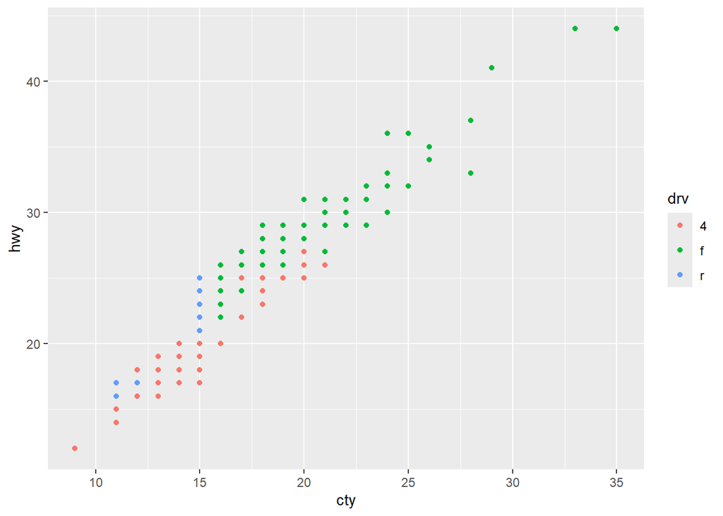

```r
ggplot(mpg, aes(x = cty, y = hwy)) +
  geom_point(aes(color = drv))
```

Facet in medium turquoise:

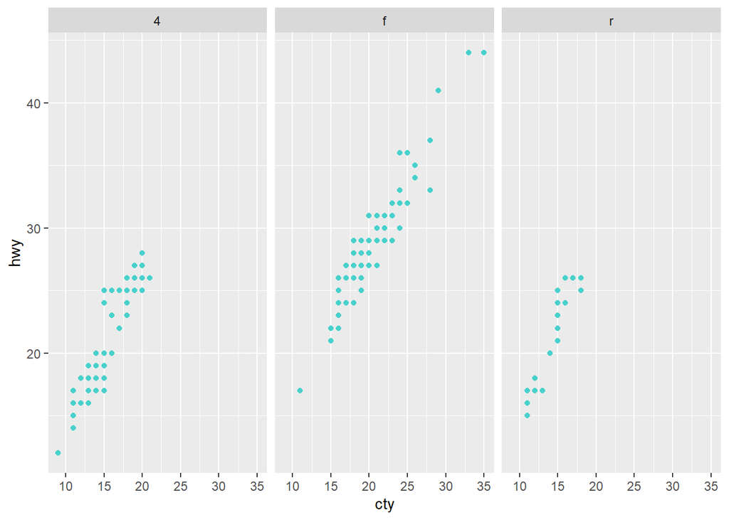

```r
ggplot(mpg, aes(x = cty, y = hwy)) +
  geom_point(color = "mediumturquoise") +
  facet_wrap(~drv)
```

What are the advantages to using faceting instead of the color aesthetic? What are the disadvantages? How might the balance change if you had a larger dataset?

**Solution**

Sometimes it’s easier to see the difference in distribution between 3 categories if they’re on separate plots. If there are too many points, for instance, it might be hard to see the category clusters compared with each other. When they’re on separate plots, the empty space helps visually with that comparison. The disadvantage is that it’s harder to compare close values this way, so for smaller datasets you both don’t necessarily need to do this and may lose out on precise differences that may make bigger impacts (related to effect size). For a larger dataset, it would probably be much easier to see patterns with faceted plots because you’d end up with a lot of points on top of each other, and jittering all the points may not be possible or helpful because of how dense the plot is.

### Exercise 4

Construct a scatterplot of `hwy` vs `cty`. Next, map a third numerical variable to `color`, then `size`, then `shape`.

**Solution**

Here is cyl mapped to color and size:

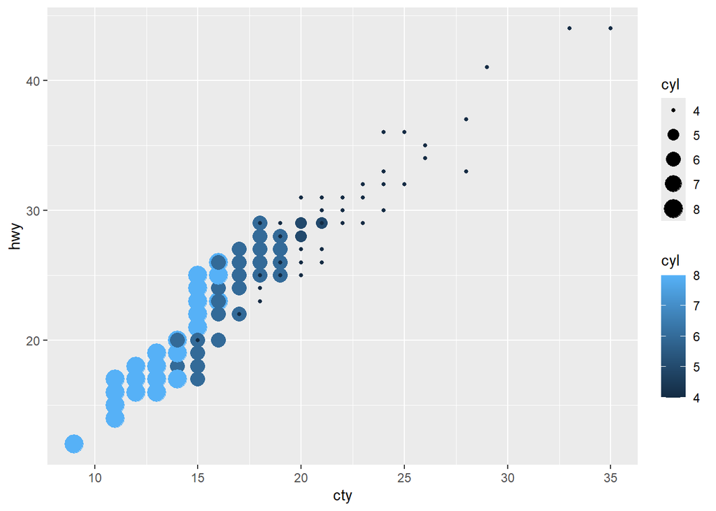

```r
ggplot(mpg, aes(x = cty, y = hwy)) +
  geom_point(aes(color = cyl, size = cyl)) +
  labs(color = "cyl", size = "cyl")
```

```r
ggplot(mpg, aes(x = cty, y = hwy)) +
  geom_point(aes(shape = cyl))
```

[output not shown]

How do the aesthetics behave differently for categorical versus numerical variables? In other words, which variable types (numeric/categorical) are appropriate to match to which aesthetics (size/shape/color)?

**Solution**

### Exercise 5

Construct a histogram of the `carat` variable in the `diamonds` dataset. Adjust the `bins` to an appropriate value. Add a `title`, remove the axis label that says `count`, and add a `caption`: “Source: ggplot2 package”.

**Solution**

### Exercise 6

Construct 2 appropriate graphics to show the relationship between `carat` and `cut`.

**Solution**

### Exercise 7

Construct a barplot of `cut`. Add in `aes(fill = carat > 0.7)`.

**Solution**

### Exercise 8

When would you use `facet_grid()` versus `facet_wrap()`? When using `facet_grid()` it is suggested that you put the variable with more unique levels in the columns. Why do you think that this practice is suggested?

**Solution**

## Case Study

Congratulations, you just landed your first job as a data analyst for Tinder! The dataset is stored in the `data` folder called `tinder_data`. A codebook, `tinder_data_codebook.csv`, provides a description of each of the variable names. This has been read in for you at the top of the document. We will learn more about importing data later in the quarter.

**Your first assignment is to determine if there is a relationship between messages sent and messages received and how this differs based on user gender.** Your boss has asked for a one paragraph summary with graphics to support your conclusions. Your boss wants all graphics *saved* into a folder named “plots”. Hint: `ggsave()`.

Since this is your first project as a data analyst you have been provided some tips and considerations for getting started:

- When approaching a research question it is important to use univariate, bivariate, and multivariate analysis (depending on the problem) to get a better understanding of your data and also identify any potential problems.
- How might the distribution of your variables impact your conclusions? Outliers? Weird values? Imbalanced classes?
- How might `coord_fixed()` and `geom_abline()` improve a graphic?
- Feel free to be creative! It is your job to answer this question and interpret conclusions in the most appropriate ways you see fit.

This dataset was provided by [Swipestats.io](https://www.swipestats.io/).

**Solution**

## Graduate Challenge

**Important**

Graduate students are required to complete this challenge. **It is optional for undergraduate students.**

- alpha = 0.25
- theme is with Google Docs Chart from [ggthemes package](https://jrnold.github.io/ggthemes/reference/index.html).

**Solution**